# Robustness and Transformations

Ryan Durfey

Monday, November 17, 2014

### Step 1: Simulate Normal Linear Model

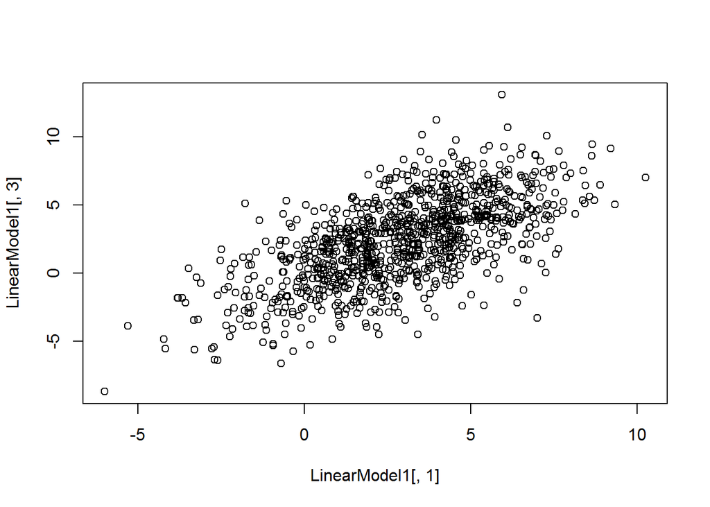

```r
## slope & intercept
a<-0.8
b<-0.1

## Model 1 (normal)
set.seed(458769)
X<-rnorm(n=1000,mean=3,sd=2.5)
Eps<-rnorm(n=1000,mean=0,sd=2.5)
Y<-a*X+b+Eps
LinearModel1<-cbind(X,Eps,Y)
plot(LinearModel1[,1],LinearModel1[,3])
```

Now we fit a linear model to the data:

```r
Model1.lm<-lm(LinearModel1[,3]~LinearModel1[,1])
summary(Model1.lm)
```

```
##
## Call:
## lm(formula = LinearModel1[, 3] ~ LinearModel1[, 1])
##
## Residuals:
##    Min     1Q Median     3Q    Max
## -8.959 -1.548 -0.006  1.675  8.288
##
## Coefficients:
##                   Estimate Std. Error t value Pr(>|t|)
## (Intercept)         0.0355     0.1180     0.3     0.76
## LinearModel1[, 1]   0.8031     0.0308    26.1   <2e-16 ***
## ---
## Signif. codes:  0 '***' 0.001 '**' 0.01 '*' 0.05 '.' 0.1 ' ' 1
##
## Residual standard error: 2.44 on 998 degrees of freedom
## Multiple R-squared:  0.406,  Adjusted R-squared:  0.405
## F-statistic:  682 on 1 and 998 DF,  p-value: <2e-16
```

The Q-Q Plot of residuals

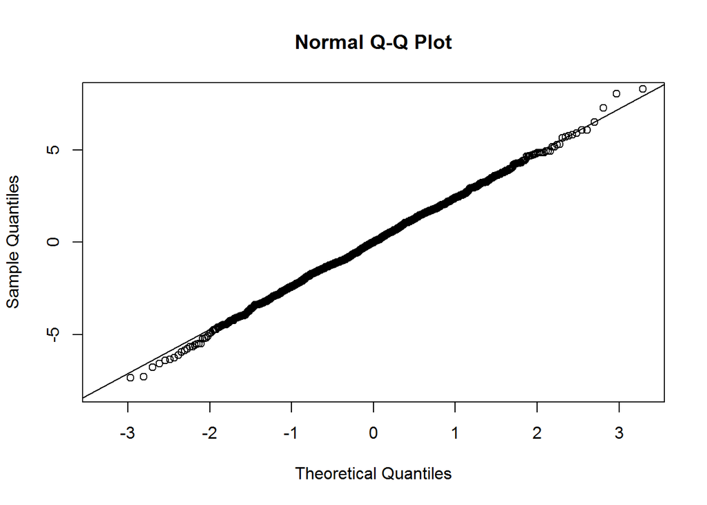

```r
qqnorm(Model1.lm$residuals,ylim=c(-8,8))
qqline(Model1.lm$residuals)
```

#### Interpretation of Q-Q Plot:

The points of the residuals seem to follow the line fairly closely. Towards the ends, it begins to falter, but not by a huge amount. Ideally, we want the points to follow the line, which represents the normal distribution, as much as possible. In this case, it is not perfect, but it appears to be fairly good.

### Step 2: Simulate the same model, with uniform residuals

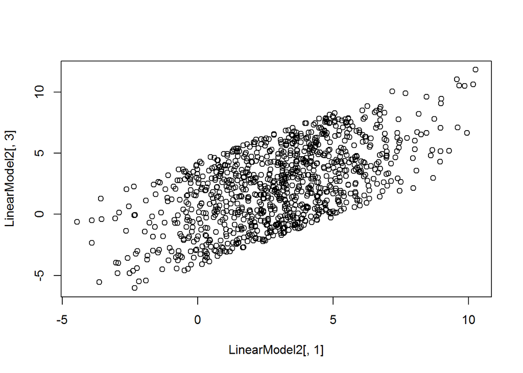

```r
## Model 2 (Normal X, Uniform Eps)
X<-rnorm(n=1000,mean=3,sd=2.5)
Eps<-runif(n=1000,min=-4.33,max=4.33)
Y<-a*X+b+Eps
LinearModel2<-cbind(X,Eps,Y)
plot(LinearModel2[,1],LinearModel2[,3])
```

Now, the linear model fitted to the data:

```r
Unif.lm<-lm(LinearModel2[,3]~LinearModel2[,1])
summary(Unif.lm)
```

```
##
## Call:
## lm(formula = LinearModel2[, 3] ~ LinearModel2[, 1])
##
## Residuals:
##    Min     1Q Median     3Q    Max
## -4.474 -2.184  0.029  2.143  4.581
##
## Coefficients:
##                   Estimate Std. Error t value Pr(>|t|)
## (Intercept)          0.170      0.123    1.37     0.17
## LinearModel2[, 1]    0.743      0.032   23.22   <2e-16 ***
## ---
## Signif. codes:  0 '***' 0.001 '**' 0.01 '*' 0.05 '.' 0.1 ' ' 1
##
## Residual standard error: 2.5 on 998 degrees of freedom
## Multiple R-squared:  0.351,  Adjusted R-squared:  0.35
## F-statistic:  539 on 1 and 998 DF,  p-value: <2e-16
```

Q-Q plot of residuals:

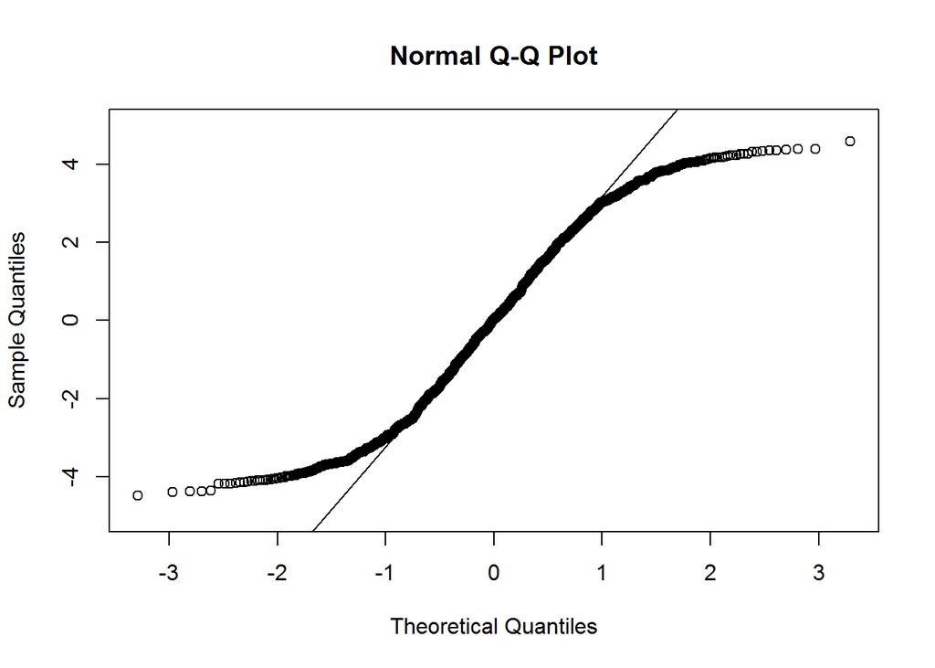

```r
qqnorm(Unif.lm$residuals,ylim=c(-5,5))
qqline(Unif.lm$residuals)
```

#### Interpretation of Q-Q plot:

Having uniform residuals changes our Q-Q plot dramatically from what we observed in the plot with normal residuals. The points follow the line through the middle section, but then fall farther and farther away as we move towards either end. Here, we see a curved, S-shaped pattern. This indicates that the distribution of the data may have short tails at both ends.

### Step 3: Different Transformations of the Output

Q-Q Plot of the output data (not the residuals, as we saw above).

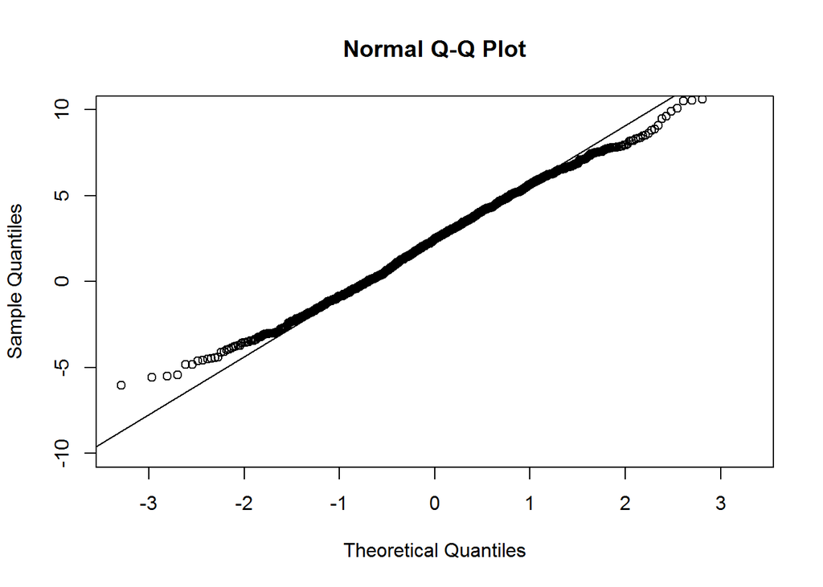

```r
## Q-Q plot of data output w/ uniform eps
qqnorm(LinearModel2[,3],ylim=c(-10,10))
qqline(LinearModel2[,3])
```

Square Root Transformation:

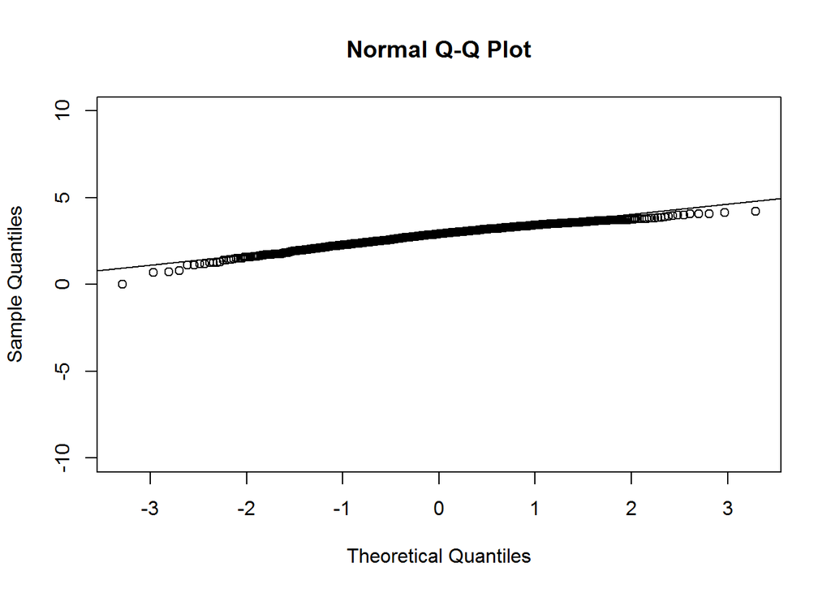

```r
## Q-Q plot after square root transformation
qqnorm(sqrt(LinearModel2[,3]-min(LinearModel2[,3])),ylim=c(-10,10))
qqline(sqrt(LinearModel2[,3]-min(LinearModel2[,3])))
```

Log Transformation:

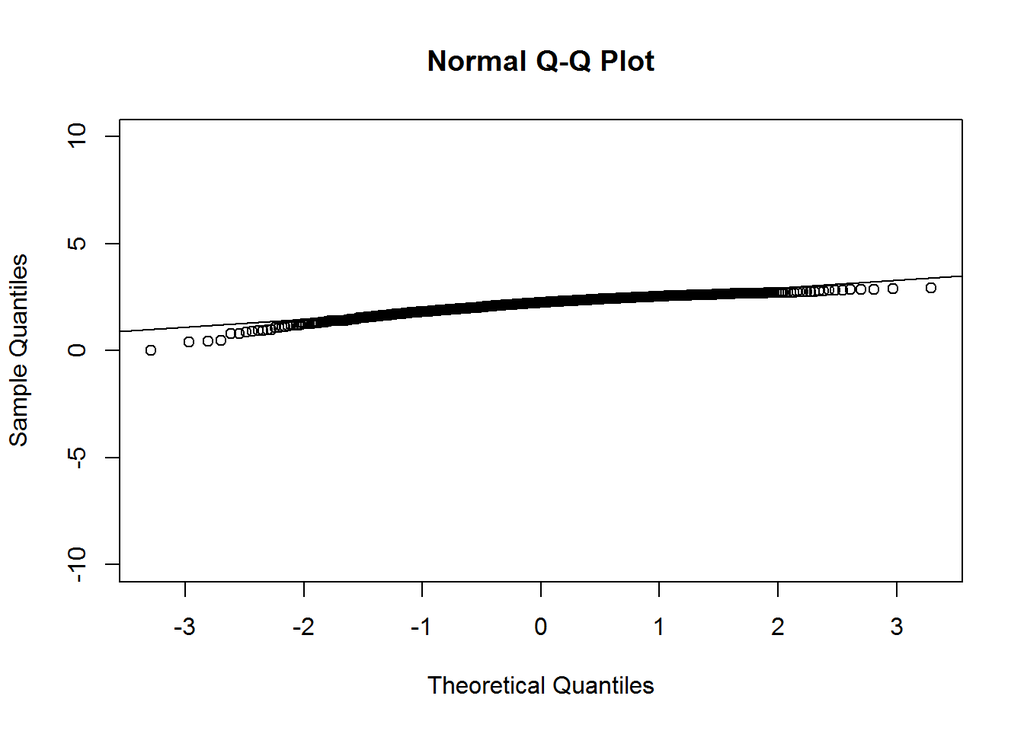

```r
## Q-Q plot after log transformation
qqnorm(log(LinearModel2[,3]-min(LinearModel2[,3])+1),ylim=c(-10,10))
qqline(log(LinearModel2[,3]-min(LinearModel2[,3])+1))
```

Inverse Transformation:

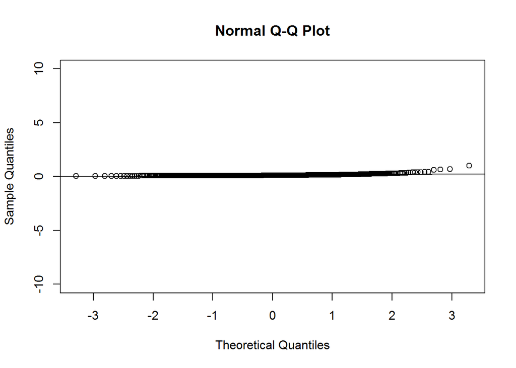

```r
## Q-Q plot after inverse transformation
qqnorm(1/(LinearModel2[,3]-min(LinearModel2[,3])+1),ylim=c(-10,10))
qqline(1/(LinearModel2[,3]-min(LinearModel2[,3])+1))
```

From the above Q-Q plots, we see that the ones that have transformed data follow near the normal line more cleanly than the original unmodified data.

### Step 4: Fit Linear Model to the Transformed Data

Now, we will fit linear models to the modified data. For the assignment, fitting one linear model to one modified dataset is required. However, for the sake of thoroughness and to be able to compare the results, we will fit linear models for each transformation.

#### Linear Model for Square Root Transformation

```r
## square root transformed linear model
Unif.lm.Mod<-lm(sqrt(LinearModel2[,3]-min(LinearModel2[,3]))~sqrt(LinearModel2[,1]-min(LinearModel2[,1])))
summary(Unif.lm.Mod)
```

```
##
## Call:
## lm(formula = sqrt(LinearModel2[, 3] - min(LinearModel2[, 3])) ~
##     sqrt(LinearModel2[, 1] - min(LinearModel2[, 1])))
##
## Residuals:
##     Min      1Q  Median      3Q     Max
## -1.9933 -0.3775  0.0408  0.3925  1.3462
##
## Coefficients:
##                                                  Estimate Std. Error
## (Intercept)                                        0.9825     0.0824
## sqrt(LinearModel2[, 1] - min(LinearModel2[, 1]))   0.6938     0.0302
##                                                  t value Pr(>|t|)
## (Intercept)                                         11.9   <2e-16 ***
## sqrt(LinearModel2[, 1] - min(LinearModel2[, 1]))    22.9   <2e-16 ***
## ---
## Signif. codes:  0 '***' 0.001 '**' 0.01 '*' 0.05 '.' 0.1 ' ' 1
##
## Residual standard error: 0.466 on 998 degrees of freedom
## Multiple R-squared:  0.346,  Adjusted R-squared:  0.345
## F-statistic:  527 on 1 and 998 DF,  p-value: <2e-16
```

```r
Unif.lm.Mod2<-lm(log(LinearModel2[,3]-min(LinearModel2[,3])+1)~log(LinearModel2[,1]-min(LinearModel2[,1])+1))
summary(Unif.lm.Mod2)
```

```
##
## Call:
## lm(formula = log(LinearModel2[, 3] - min(LinearModel2[, 3]) +
##     1) ~ log(LinearModel2[, 1] - min(LinearModel2[, 1]) + 1))
##
## Residuals:
##     Min      1Q  Median      3Q     Max
## -1.5550 -0.2309  0.0417  0.2470  1.0566
##
## Coefficients:
##                                                     Estimate Std. Error
## (Intercept)                                           0.8032     0.0616
## log(LinearModel2[, 1] - min(LinearModel2[, 1]) + 1)   0.6602     0.0292
##                                                     t value Pr(>|t|)
## (Intercept)                                            13.1   <2e-16 ***
## log(LinearModel2[, 1] - min(LinearModel2[, 1]) + 1)    22.6   <2e-16 ***
## ---
## Signif. codes:  0 '***' 0.001 '**' 0.01 '*' 0.05 '.' 0.1 ' ' 1
##
## Residual standard error: 0.315 on 998 degrees of freedom
## Multiple R-squared:  0.339,  Adjusted R-squared:  0.338
## F-statistic:  511 on 1 and 998 DF,  p-value: <2e-16
```

```r
lm1<-1/(LinearModel2[,3]-min(LinearModel2[,3])+1)
lm2<-1/(LinearModel2[,1]-min(LinearModel2[,1])+1)
Unif.lm.Mod3<-lm(lm1~lm2)
summary(Unif.lm.Mod3)
```

```
##
## Call:
## lm(formula = lm1 ~ lm2)
##
## Residuals:
##     Min      1Q  Median      3Q     Max
## -0.4117 -0.0316 -0.0120  0.0195  0.7806
##
## Coefficients:
##             Estimate Std. Error t value Pr(>|t|)
## (Intercept)  0.05540    0.00428    12.9   <2e-16 ***
## lm2          0.51203    0.02879    17.8   <2e-16 ***
## ---
## Signif. codes:  0 '***' 0.001 '**' 0.01 '*' 0.05 '.' 0.1 ' ' 1
##
## Residual standard error: 0.059 on 998 degrees of freedom
## Multiple R-squared:  0.241,  Adjusted R-squared:  0.24
## F-statistic:  316 on 1 and 998 DF,  p-value: <2e-16
```

Q-Q Plots of the residuals of the transformed models and original linear model (with uniform residuals).

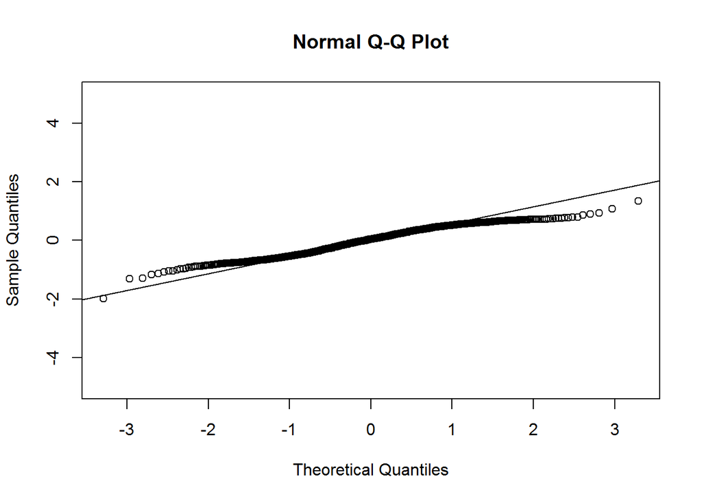

```r
## Q-Q plot from square root transformed model residuals
qqnorm(Unif.lm.Mod$residuals,ylim=c(-5,5))
qqline(Unif.lm.Mod$residuals)
```

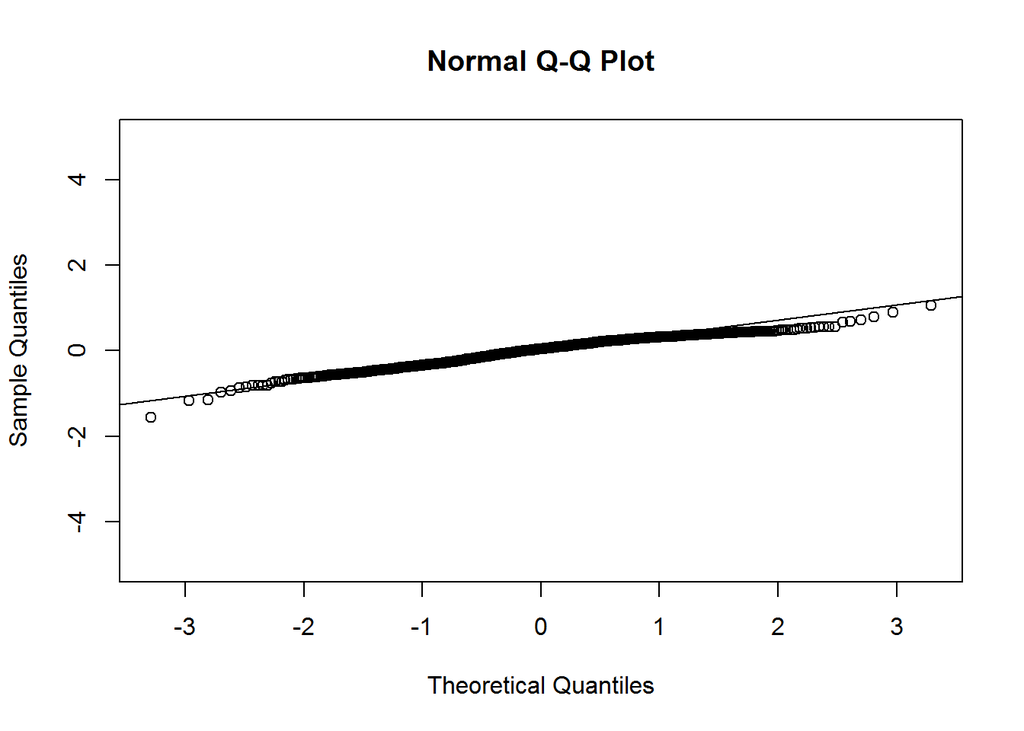

```r
## Q-Q plot from log transformed model residuals
qqnorm(Unif.lm.Mod2$residuals,ylim=c(-5,5))
qqline(Unif.lm.Mod2$residuals)
```

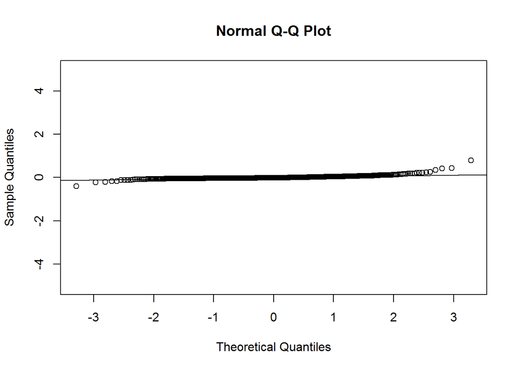

```r
## Q-Q plot from inverse transformed model residuals
qqnorm(Unif.lm.Mod3$residuals,ylim=c(-5,5))
qqline(Unif.lm.Mod3$residuals)
```

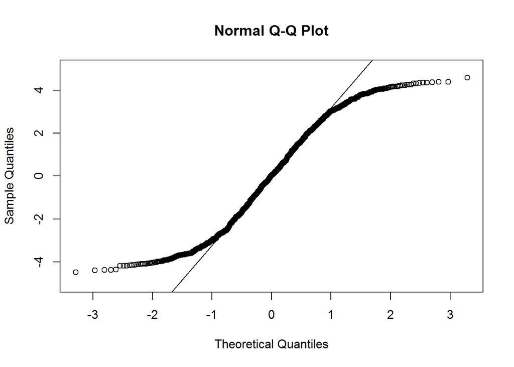

```r
## Q-Q plot from original model
qqnorm(Unif.lm$residuals,ylim=c(-5,5))
qqline(Unif.lm$residuals)
```

### Analysis:

From the linear model summaries, we see that the models utilizing transformed data have an advantage of having a more significant intercept parameter. The residual standard errors are also lower than in the original model. One area where the transformed models do not have an obvious advantage is the R-Squared values. These values are lower for the transformed models, but not by a lot. Also, the Q-Q plots associated with with the transformed models look better than the plot from the original model. Overall, using transformed data to fit a linear model seems to be advantageous.